# The Promotional Effects of Live Streams by Twitch Influencers

Converted from PDF `Huang-TwitchLivestreamPromotion-2025-MKSC.pdf` · 18 pages · anchors: page `#pN`, block `#pN-bK`

Page 1

### **The Promotional Effects of Live Streams by Twitch Influencers**

#### **Yufeng Huang,<sup>a</sup>Ilya Morozov<sup>b,</sup>***

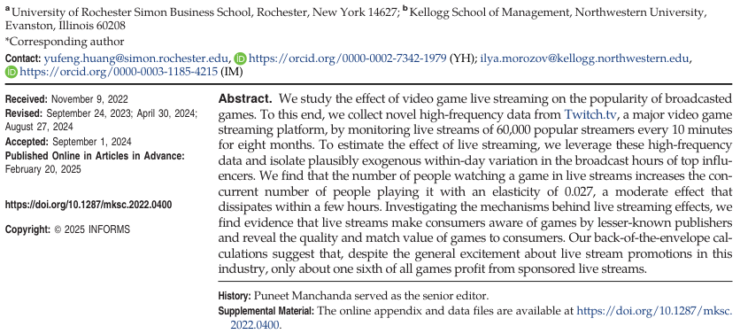

NOTE: complex table shown as an image of the PDF; the text below is a rough machine extraction and may be mis-aligned.

**extracted text (unreliable layout)**

#### **Keywords: live streaming** <sup>•</sup> **influencer marketing** <sup>•</sup> **video games**

**1. Introduction** Over the past few years, live streaming has grown into a widely popular media format. To capitalize on this rapid growth, many companies hire influencers to pro mote their products in live streams. Video game pub lishers, for example, often advertise their titles in live streams on Twitch—the world’s largest video game streaming platform. Similarly, companies from a broad range of industries, from cosmetics to auto manufactur ing, promote their products on live commerce plat forms such as Taobao Live, Amazon Live, and TikTok Live.<sup>1</sup> In fact, live commerce has already grown into a $423 billion industry in China and is expected to reach $68 billion in the United States by 2026.<sup>2</sup>

There seems to be a broad consensus among practi tioners that live stream promotions yield high returns. To support this view, practitioners often cite anecdotes where hiring an influencer to promote a product in live streams reportedly generated an extraordinary return on investment (ROI) of 150%–300%.<sup>3</sup> However, these selectively reported success stories may overstate the average effectiveness of live stream promotions. Addi tionally, if firms use such promotions to advertise products that are already growing in popularity, these anecdotes may create a false appearance that live streams drive sales. Despite these selection and

endogeneity concerns, the academic literature has made few attempts to move beyond suggestive anec dotes and estimate the causal effects of live stream pro motions on product demand.

In this paper, we estimate the effect of live streaming in the video game industry. We pursue three main goals. First, we estimate the average effect of video game live streams on the number of people playing the broadcasted games. Second, moving beyond this average effect, we estimate and describe the distribution of live streaming effects across games of different types. Recovering this distribution enables us to study when and why live streams bring additional players into broadcasted games, thus unveiling the mechanisms behind these effects. Third, we use these estimated live streaming effects to evaluate the expected returns of game publishers from promoting their games in sponsored live streams.

To achieve these goals, we collect unique highfrequency data from Twitch.tv. Twitch influencers, also known as “streamers,” broadcast their gaming sessions live by sharing their screen and web camera video while commenting on the game in real time. We construct an original high-frequency data set on Twitch streaming and video game usage. For eight months, from May to December 2021, we continuously monitor 60,000 prese lected Twitch streamers, gathering information about

916

**MARKETING SCIENCE Vol. 44, No. 4, July–August 2025, pp. 916–932 ISSN 0732-2399 (print), ISSN 1526-548X (online) https://pubsonline.informs.org/journal/mksc**

Page 2

their live streams every 10 minutes. We record which streamers are live, which games they are streaming, and the number of viewers watching each live stream. During the same period, we collect data on the number of concurrent players in each game with the same 10-minute frequency. We complement these data sets with individual-level data on Twitch stream viewership and online purchases of video games.

Estimating the causal effect of live streams poses an empirical challenge because streamers can strategically choose which games to broadcast and when to do so. As video games gain and lose popularity due to their natural life cycles and in-game events, streamers may choose to broadcast games that are on the rise to grow their own viewership. Additionally, video game pub lishers may encourage streamers to broadcast trending games through official sponsorships or informal incen tives, such as in-game perks. This strategic behavior by both firms and streamers can create a correlation between game usage and live streaming, which may falsely suggest that live streams make broadcasted games more popular.

An ideal experiment to address this endogeneity con cern would make streamers broadcast random games at random times of the day. Our empirical strategy mimics this ideal experiment. We assume that, although streamers might strategically decide whether to go live and which games to broadcast on any given day, their exact broadcast times within a day do not respond to short-term changes in game popularity. Streamers might adjust their broadcast hours to accommodate other demands on their time, such as university classes and part-time jobs. They might also finish broadcasting earlier than planned due to fatigue or later than planned if events that occur in the game extend their gaming sessions. Because of these idiosyncratic reasons, streamers broadcast at irregular hours, thus shifting when their audiences get exposed to a live stream of the game they broadcast on that day. Leveraging our high- frequency data, we use this within-day variation in the broadcast hours of top streamers as an exogenous shifter of the game’s viewership on Twitch. This empiri cal strategy enables us to obtain plausibly causal esti mates of the effect of live streaming on game usage.

We first estimate the average effect of organic live streams, which are not solicited by any game publisher. We find that organic live streams bring additional players into the broadcasted games with an elasticity of 0.027. Given this elasticity, we compute that the aver age broadcast by a top streamer increases the number of people playing the broadcasted game by around 3%. This effect becomes 30% weaker every subsequent hour and dissipates to 10% of its initial magnitude within about seven hours. Thus, organic live streams somewhat increase game usage, but the effect is short lived.

Next, to understand when and why live streams increase game usage, we estimate how streaming effects vary with game characteristics using generalized ran dom forests (GRF) (Athey et al. 2019). Live streams may raise awareness of games from lesser-known publish ers, which have modest marketing budgets and do not advertise their titles as much as major game con glomerates. Consistent with this conjecture, we find live streams to be particularly effective for games from small publishers that have released two games or fewer. Additionally, because live streams often last for hours and showcase games in great detail, they may reveal the game’s quality and match value to consumers. In line with these conjectures, we find live streams to be more effective for high-quality games, defined as those with average critic ratings above 80/100. We also find stronger streaming effects for “niche” games, defined as those with high standard deviations of consumer rat ings. These findings suggest that from watching Twitch streams, consumers may discover that the broadcasted game is of high quality; and even when it has mediocre quality, some consumers may learn that the game matches their specific tastes.

Our results have several managerial implications regarding the effects of live stream promotions in the video game industry. First, practitioners should be wary of the widespread anecdotes in which sponsored live streams supposedly generated high ROI. Because we estimate the entire distribution of live streaming effects, our results paint a more complete picture: spon sored live streams can be effective for some games, but they generate positive ROI for only about one sixth of games. Second, practitioners should carefully choose which video games to promote in live streams. Our results suggest sponsored live streams might be particu larly effective at promoting highly rated games and games with niche appeal. They can also help lesser- known publishers make consumers aware of their games. Third, we show that organic live streams increase

**Huang and Morozov:** *Promotional Effects of Live Streams by Twitch Influencers* Marketing Science, 2025, vol. 44, no. 4, pp. 916–932, © 2025 INFORMS 917

Page 3

the usage of broadcasted games by about six times as much as sponsored live streams. Thus, publishers should consider incentivizing organic live streams by making their games easy to stream or offering in-game perks for broadcasting the game organically.

This paper contributes to the literature on the effec tiveness of influencer marketing by estimating the effects of live streaming on the usage and sales of promoted products. Live streaming is an emerging form of influencer marketing that has gained signifi cant momentum over the last few years. Although the effects of live streams have not yet been well studied, several papers have estimated the effects of video con tent produced by influencers on product popularity. Li et al. (2025) study the effect of YouTube gaming videos on the usage and purchases of Steam video games, whereas Yang et al. (2021) develop an algorithm that predicts how the content of TikTok videos shapes their promotion effects. Both papers estimate promotion effects by using within-product variation in the dates of video uploads, and both exploit institutional fea tures of platforms to address the endogeneity of the video upload timing.<sup>4</sup> By contrast, we collect novel high-frequency data and leverage plausibly exoge nous within-day variation in streamers’ broadcast hours. This empirical strategy enables us to bring the analysis to a level of granularity that alleviates the endogeneity concerns.<sup>5</sup>

More broadly, this paper also contributes to the small but growing literature on the emerging phenom enon of live streaming. Most existing papers study the drivers of viewership and engagement in live streams. For instance, the prior work shows that consumers pre fer watching live streams over recorded content (Cong et al. 2021). Viewers engage more with live streams they perceive as more popular (Lu et al. 2021), live streams where the broadcaster exhibits positive emo tions (Lin et al. 2021), and live streams of e-sports events filled with suspense and surprise (Simonov et al. 2023). In contrast to these papers, we study whether live streams boost the popularity of products promoted in these streams, and we evaluate the profitability of sponsored live streams. In this sense, we make one of the early attempts to evaluate the effectiveness of live streaming as a marketing channel.

**2. Measuring Twitch Live Streaming and Game Popularity 2.1. What Is Twitch?** Twitch.tv is an Amazon-owned video live streaming platform mostly dedicated to streaming video games. The platform experienced tremendous growth over the last decade. In 2012, it hosted only several thousand registered channels and 70,000 concurrent viewers. By 2022, it had grown into a video streaming giant that

hosts more than 1,000,000 live channels and attracts almost three million viewers at any point in time.<sup>6</sup> This growth was driven by the increasing worldwide popu larity of esports and was further amplified by the stay- at-home orders of 2020–2021, which made millions of people around the globe look for new entertainment options. At the time of this writing, Twitch remains the world’s largest video game streaming platform, accounting for 63.6% of total hours of content watched and hosting 91.1% of all video game streaming content outside China.<sup>7</sup> Twitch often attracts four to six million viewers during peak hours, which is more than the major TV networks Fox News, CNN, and MSNBC put together.<sup>8</sup>

Twitch streamers broadcast their gameplay live by sharing their screen and web camera video. Figure 1 shows what these live streams look like from the view ers’ perspective. Streamers play video games live while commenting on the gameplay and responding to view ers’ chat messages. Some streamers are professional e-sports players who always broadcast the same game and impress viewers with their gaming skills. One example is a professional “Fortnite” player, Ninja, who once had 650,000 people watching him play “Fortnite” live (Vincent 2018). Other streamers play different games every week to introduce variety to their content. To make broadcasts more engaging, streamers often attempt to make their content funny and entertaining (see Online Appendix Figure A.3). One such example is DrDisrespect, a streamer whose vibrant personality and unique look—a mullet hairstyle, 80s-style mus tache, and polarized sunglasses—made him one of the most popular streamers on the platform.

**2.2. Live Streaming Data from Twitch** We monitored video game streaming on Twitch for almost eight months between May 11, 2021, and December 31, 2021.<sup>9</sup> Twitch API limited us to collecting real-time data on at most 60,000 streamers. We there fore started data collection by preselecting streamers as follows. We monitored all active live streams on Twitch and their average viewership during the preliminary period of April 22–28, 2021. Of more than 900,000 strea mers we observed in this period, we preselected 60,000 streamers, randomly drawing them with probabilities proportional to each streamer’s average number of viewers in this preliminary period (see Online Appen dix A.1).

Then, during the main data collection period, we tracked 60,000 preselected streamers by sending high- frequency requests via Twitch API. Every 10 minutes, we requested the status of each streamer (online or off line), the concurrent number of viewers, the game they were streaming, and the title of each stream. Because most of the preselected streamers went live on Twitch at least once during the data collection period, our

**Huang and Morozov:** *Promotional Effects of Live Streams by Twitch Influencers* 918 Marketing Science, 2025, vol. 44, no. 4, pp. 916–932, © 2025 INFORMS

Page 4

[figure not shown]

NOTE: figure/graphic rendered as an image from the PDF; its content is not machine-readable text. Caption (if any) follows as the next block.

sample covers 96.8% of the streamers we attempted to track (58,060 of 60,000). To reduce the computational burden of our analysis, we aggregate these data to hourly observations, averaging the number of concur rent viewers across 10-minute intervals within each hour. Our estimation results remain similar when we use the original 10-minute intervals (see Section 3.3 for details).

Throughout the paper, we use these Twitch API data to estimate the total number of viewers and streamers of each game in any given hour. Because we randomly sampled streamers into our sample from a larger popu lation of 900,000 streamers, we need to rescale the view ership and streamer counts using appropriate sampling probabilities so that the resulting values accurately rep resent each game’s total viewership and streaming activity on Twitch. Online Appendix A.2 details this reweighting procedure and validates our estimates of the total viewership against external data.

Table 1 describes the live-streaming activity on Twitch of the 15 most popular streamers. We measure streamer popularity using the average number of concurrent viewers, and we refer to the top 5% of most popular streamers as “top streamers.” The table reports the pri mary game of each streamer, defined as a game that this streamer broadcasted for the largest number of hours. Although many top streamers broadcast hit games such as “Grand Theft Auto V” and “Minecraft,” some have risen to the top by broadcasting lesser-known indie games such as “Jump King.” Each of the top 15 streamers

attracts at least 30,000 viewers at any given time and often more than 100,000 viewers in peak times.<sup>10</sup>

Next, Table 2 summarizes the distribution of average daily streaming activity, viewership, and usage across games. The average game is streamed for 488 hours a day in 196 different broadcasts, two of which are broadcasts by top streamers. Twitch users watch the broadcasts of the average game for a total of 27,357 hours per day.

**2.3. Game Usage Data from Steam** We also collected data on the number of people playing each video game at any given time. We collected these data from Steam (steampowered.com)—the world’s most popular online video game platform that attracts 62.6 million active players every day.<sup>11</sup> Because consu mers have to log into their accounts to play Steam games, the platform collects accurate data on the num ber of concurrent players in each game.

We first preselected 599 games that were most fre quently streamed and watched on Twitch during the

**Figure 1.** (Color online) Famous Streamer Pokimane Broadcasting Her Gameplay of the Shooter Game “Valorant” on Twitch.tv

*Notes.* The main window shows the gameplay that Pokimane is broadcasting live. The window in the top-left corner shows the streamer’s web camera video. The vertical window on the right is the chat where viewers can send the streamer text messages in real time.

**Huang and Morozov:** *Promotional Effects of Live Streams by Twitch Influencers* Marketing Science, 2025, vol. 44, no. 4, pp. 916–932, © 2025 INFORMS 919

Page 5

preliminary period of April 22–28, 2021 (see Online Appendix A for details). Then, between May 11, 2021 and December 31, 2021, we sent high-frequency requests to Steam API to retrieve the number of concurrent players of these games every 10 minutes, synchronized with Twitch data collection. As with the total viewer counts, we average the number of concurrent players across the 10-minute intervals within each hour. Table 2 shows that gamers play the average game on Steam for 130,794 hours per day, about five times as many hours as they watch it on Twitch.

**2.4. Video Game Attributes** We additionally collected data on video game attri butes, including each game’s publisher, release date,

and daily price history from Steam, as well as customer ratings and professional critic ratings from Metacritic. com. To proxy a game’s quality, we use its average Metacritic rating, a widely recognized quality metric analogous to Rotten Tomatoes ratings for movies. We compute the regular price of a game as the 95th percen tile of its daily prices observed during the main data collection period.

More than half of all games in our sample were released within three years prior to data collection. About 48% all games were produced by indie publish ers that have released at most one other game.<sup>12</sup> Further more, 13% games are free to play, and the median regular price of paid games is $20. The Metacritic ratings range from 20/100 to 97/100, with a median of 80/100.

**Table 1.** Streaming Activity on Twitch

|  |  |  |  |  | Daily | Stream | Stream |
| --- | --- | --- | --- | --- | --- | --- | --- |
|  |  | Primarygame | Average | Maximum | streamhours | starttime | endtime |
|  |  | streamedon | concurrent | concurrent | Avg. | Avg. | Avg. |
| No. | Twitchstreamer | Twitch .tv | viewers | viewers | (Std Dev.) . | (Std Dev.) . | (Std Dev.) . |
| 1 | AuronPlay | Minecraft | 104807 , | 318181 , | 39(09) . . | 15:20(0:50) | 19:20(0:50) |
| 2 | RanbooLive | Minecraft | 75695 , | 234626 , | 25(17) . . | 21:00(2:50) | 23:40(3:10) |
| 3 | Ibai | Minecraft | 75297 , | 1538645 , , | 49(34) . . | 16:30(2:50) | 21:20(2:30) |
| 4 | Sapnap | Minecraft | 72992 , | 186592 , | 20(15) . . | 22:20(3:20) | 0:20(2:40) |
| 5 | xQcOW | GTAV | 72479 , | 175453 , | 156(77) . . | 14:00(7:20) | 5:40(4:20) |
| 6 | loud coringa _ | GTAV | 65029 , | 307450 , | 76(55) . . | 21:10(5:20) | 4:50(3:00) |
| 7 | RocketLeague | RocketLeague | 57650 , | 208124 , | 50(23) . . | 18:10(3:30) | 23:10(3:40) |
| 8 | Flashpoint | CS:GO | 52655 , | 128800 , | 73(34) . . | 15:10(1:50) | 22:30(3:30) |
| 9 | Asmongold | WOW | 52135 , | 135042 , | 74(17) . . | 15:10(1:20) | 22:40(2:20) |
| 10 | thisisnotgeorge | Minecraft | 50243 , | 113707 , | 35(44) . . | 21:40(7:00) | 1:10(6:20) |
| 11 | MontanaBlack88 | GTAV | 48523 , | 159731 , | 62(32) . . | 15:20(2:50) | 21:30(2:20) |
| 12 | Rubius | Minecraft | 44379 , | 207592 , | 53(19) . . | 17:30(1:00) | 22:50(1:50) |
| 13 | Mizkif | JumpKing | 35246 , | 189851 , | 59(33) . . | 20:20(2:30) | 2:20(3:10) |
| 14 | karlnetwork | Minecraft | 33127 , | 93412 , | 55(67) . . | 20:40(8:50) | 2:10(7:50) |
| 15 | shroud | Valorant | 31043 , | 334836 , | 113(65) . . | 16:30(5:20) | 3:50(5:10) |
|  | Average(top5%streamers) |  | 2372 , | 17967 , | 82(45) . . | 15:20(4:00) | 23:40(4:20) |
|  | Average(allstreamers) |  | 148 | 1276 , | 54(38) . . | 17:40(4:20) | 23:00(4:20) |

NOTE: table converted from PDF layout to HTML text; cell boundaries are reconstructed. See PDF if exact alignment matters.

*Notes.* This table summarizes live streaming activity on Twitch.tv, both overall and for the 15 most popular streamers. We measure streamer popularity using the average number of concurrent viewers in our data set. The primary game of each streamer is defined as a game that this streamer broadcasted for the largest number of hours. The last two columns show the average start and end times of live streams and report the standard deviations of start and end times in the parentheses. The time is in the UTC time zone. The last two rows report the averages (1) across the top 5% most popular streamers and (2) across all 58,060 tracked streamers. Avg., average; Std. Dev., standard deviation.

**Table 2.** Average Daily Streaming Activity, Viewership, and Usage Across games

|  | Mean | Standarddeviation | P5 | P25 | P50 | P75 | P95 |
| --- | --- | --- | --- | --- | --- | --- | --- |
| No. streams (all) | 196 | 951 | 0 | 3 | 25 | 96 | 601 |
| No. streams (top 5%) | 2 | 14 | 0 | 0 | 0 | 1 | 7 |
| Hoursstreamed | 488 | 2391 , | 0 | 6 | 48 | 239 | 1600 , |
| Hoursviewed | 27357 , | 201858 , | 23 | 335 | 1800 , | 7678 , | 66486 , |
| Hoursplayed | 130794 , | 725737 , | 23 | 1130 , | 7414 , | 53106 , | 439488 , |

NOTE: table converted from PDF layout to HTML text; cell boundaries are reconstructed. See PDF if exact alignment matters.

*Notes.* This table shows the distribution of daily average streaming activity, viewership, and usage across the 599 Steam games in our sample. To estimate the number of people watching a stream at any given point in time, we multiply the number of current viewers obtained from Twitch API by 10 minutes: the frequency of data collection. We compute the time spent streaming and playing a game in a similar fashion. We adjust for the sampling weights when computing the daily average number of streams, stream hours, and watch hours (see Online Appendix A.2).

**Huang and Morozov:** *Promotional Effects of Live Streams by Twitch Influencers* 920 Marketing Science, 2025, vol. 44, no. 4, pp. 916–932, © 2025 INFORMS

Page 6

**2.6. Individual-Level Stream Viewership and Online Purchases** We augmented our main data set with individual-level data from the 2019–2020 U.S. Comscore Web-Behavior Panel. In these data, we observe the games consumers watch on Twitch and the games they purchase from major online retailers. We limit our analysis to 8,611 consumers who purchased at least one video game online and visited Twitch.tv at least once. The average consumer in this sample visited Twitch every other day and watched live streams of 2.5 different games per visit. Of 599 Steam games tracked in our high- frequency data, 203 games were purchased at least once. We observe 5,786 purchases in total across seven major online retailers: Steam (72% of transactions), Amazon (13%), Walmart (6%), Best Buy (6%), Game Stop (2%), Target (2%), and Microsoft (0.3%). We only use Comscore data to estimate the conversion rate for our ROI calculations in Section 5.

**2.7. Subscription Revenues of Individual Streamers** We also collected data on the daily number of active subscribers of each streamer from twitchtracker.com. To this end, we tracked the number of active subscrip tions for the 10,000 most-subscribed streamers on a daily basis, from May 11, 2021 to November 6, 2021. Based on these data, we estimated that the average top streamer has 4,312 subscriptions and earns $14,058 per month in subscription revenues. Dividing this average revenue by the total number of broadcasting hours per month, we estimated that the average top streamer earns $144 per hour of live streaming.<sup>14</sup> In Section 5, we use this $144 estimate as a rough measure of spon sorship costs. See Online Appendix A.3 for details.

**3. Effects of Live Streaming 3.1. Empirical Strategy** In this section, we study the extent to which video game live streams on Twitch bring additional players into the broadcasted games. In the ideal experiment, we would make streamers broadcast random games at random times of the day, and we would measure the corresponding lift in the number of players during their broadcasts. Such an experiment is not feasible because neither we nor Twitch can control when strea mers go live and which games they broadcast.

We mimic this ideal experiment using the following instrumental variable (IV) strategy. Leveraging our high-frequency data, we control for game-date fixed effects in order to isolate within-day variation in the broadcast activities of top streamers. As before, we define top streamers as the 5% streamers with the high est number of average concurrent viewers (see Section 2.2). We then use the number of top streamers who broadcast a game in a given hour as an IV for this game’s Twitch viewership in that hour. Top streamers attract large audiences regardless of which games they broadcast and when they go live. Therefore, when top streamers start to broadcast a game, they expose their audiences to a live stream of this game, thus increasing the total number of people watching this game on Twitch. Our IV strategy captures these viewership changes and measures the extent to which they increase the number of people playing the broadcasted game.

Our main identifying assumption is that, although streamers may strategically choose whether to go live and which games to broadcast on any given day, the hours when they broadcast a game within a given day do not respond to within-day shocks to this game’s popularity. Under this exogeneity assumption, our IV strategy yields consistent estimates of the effect of live stream viewership on game usage.

We view this exogeneity assumption as plausible in the context of video game live streaming. Instead of working regular hours, many streamers start working whenever it is convenient for them given other demands on their time, such as university classes and part-time jobs. Once they start streaming, they may not be able to react to the changes in game popularity in real time because doing so would require them to monitor popu larity trends on Twitch while actively playing another game and engaging with their audience. Streamers may also finish broadcasting earlier than planned due to fatigue or later than planned if events that occur in the game extend their gaming sessions. These idiosyncratic reasons lead Twitch streamers to broadcast games at irregular hours of the day for reasons that are plausibly exogenous with respect to the unobserved game popu larity shocks.<sup>15</sup>

**Huang and Morozov:** *Promotional Effects of Live Streams by Twitch Influencers* Marketing Science, 2025, vol. 44, no. 4, pp. 916–932, © 2025 INFORMS 921

Page 7

possibility that some streamers follow regular sche dules and that certain games have peak streaming times, we still observe significant residual variation in broadcast times.

We assume this variation in broadcast times does not respond to within-day changes in the popularity of specific games. One might worry that streamers time their broadcasts to coincide with in-game events such as tournaments or new version releases, which may occur at varying times on different days. If streamers aligned their broadcast times with such events, we would likely see that streamers who broadcast the same game on the same day start and end their streams at around the same time. Contrary to this prediction, we find that game-date fixed effects explain only 10%–12% variation in the start and end times, implying top strea mers rarely syncronize their broadcasts (see Online Appendix Table 4). Additionally, Online Appendix Figure 12 compares broadcast hours of several top strea mers, making it clear that streamers rarely syncronize their broadcasts. We thus conclude that the variation in our IVs is unlikely to be driven by unobserved game- specific events that may simultaneously influence the game’s viewership and usage.

Next, we demonstrate that top streamers’ broadcasts increase the number of people watching and playing the broadcasted game. To visualize these effects, we identify all days on which a given game was broad casted by at most one top streamer. We call this top

**Figure 2.** (Color online) Daily Broadcast Times of Top Twitch Streamers

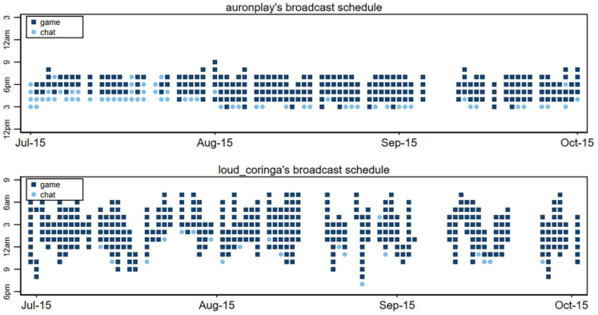

NOTE: figure/graphic rendered as an image from the PDF; its content is not machine-readable text. Caption (if any) follows as the next block.

*Notes.* This figure illustrates the daily work hours of two streamers with nicknames AuronPlay and loud_coringa. Each graph shows hours of the day in which a streamer was live on Twitch (squares), with the horizontal axis showing the date and the vertical axis showing the hour of the day. Dark squares indicate when the streamer was broadcasting a game, and light squares indicate when the streamer was “just chatting” with the audience.

**Huang and Morozov:** *Promotional Effects of Live Streams by Twitch Influencers* 922 Marketing Science, 2025, vol. 44, no. 4, pp. 916–932, © 2025 INFORMS

Page 8

streamer’s broadcast a *focal stream*. We select focal streams such that no other top streamer broadcasts the same game within 10 hours before the start and 20 hours after the start of the focal stream. We then exam ine the change in the number of viewers and players of the broadcasted game during this 30-hour window. Although these selection criteria help isolate the effects of the focal stream, we only use them for visualization purposes and relax them in the formal regression analysis.

Figure 3(a) shows the number of viewers before and after the start of the focal stream. The figure plots the estimated coefficients from a linear model that regresses the log number of viewers on a set of dummies captur ing one-hour periods for the 10 hours before and 20 hours after the start of a focal stream. We normalize the coefficient for the hour right before the stream’s start to zero. To account for systematic variation in game popu larity that might correlate with live stream viewership, we control for game-date, game–hour-of-the-day, and time fixed effects. These fixed effects are the same as in our formal model, which we explain in detail in Section 3.2.

As Figure 3(a) shows, the number of viewers remains roughly constant before the start of the focal stream, increases sharply after its start, remains high for two hours, and then gradually declines to its initial level before the stream. Figure 3(b) shows that the number of players of the broadcasted game increases after the start of a focal stream, suggesting live streams indeed bring additional players into the broadcasted games.<sup>16</sup> Notably, the number of players does not immediately increase after the stream starts. Instead, it

increases gradually and peaks at about one to two hours after the start, slowly returning to its initial level in about five hours. We interpret this lagged response as preliminary evidence that the increase in stream viewership generates persistent but short-lived effects on game usage. Motivated by this observation, we now develop a formal model that allows for, but does not assume, the persistent effects of Twitch viewership.

**3.2. Empirical Model and Estimation** We specify a model that captures both the immediate effect of Twitch viewership on game usage as well as its persistent effects in subsequent time periods. Let *j* index games and let *t* index hour-long time periods. We model the number of players in game *j* at time *t* as follows:

log(1 + Players*jt*)  β log(1 + *Vjt*(δ))

+ λ*j*, *d*(*t*) + *µj*, *h*(*t*) + η*t* + ε*jt*, (1)

**equation / math rendering (image)**

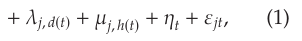

NOTE: contains mathematical notation; text above is the PDF text layer and symbols may be mis-extracted. Image shows the original.

where *Vjt*(δ) is the *total viewership stock* explained below; λ*j*,*d*(*t*) are game-date fixed effects, where *d*(*t*) is the date at time *t*; *µj*,*h*(*t*) are game–hour-of-the-day fixed effects, where *h*(*t*) is the hour of the day at time *t*; η*t* are time fixed effects; and ε*jt* are idiosyncratic shocks.

The game-date fixed effects λ*j*,*d*(*t*) capture that games become more or less popular over time, either due to their natural life cycles or because of temporary changes such as in-game events or new version releases, which affect both viewership and usage. The game–hour-of- the-day fixed effects *µj*,*h*(*t*) account for predictable within-day variation in game popularity, which might occur, for example, because different games are played

**Figure 3.** (Color online) Number of Viewers and Players Before, During, and After a Focal Stream

(b) Log Players (a) Log Viewers

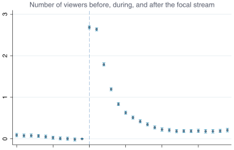

NOTE: figure/graphic rendered as an image from the PDF; its content is not machine-readable text. Caption (if any) follows as the next block.

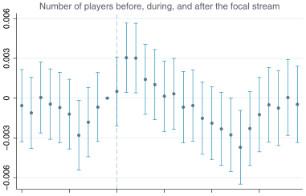

NOTE: figure/graphic rendered as an image from the PDF; its content is not machine-readable text. Caption (if any) follows as the next block.

*Notes.* These graphs visualize the estimated regression coefficients from a linear model that regresses the log number of concurrent viewers (left) or the log number of concurrent players (right) on a set of dummy variables capturing one-hour time periods for 10 hours before and 20 hours after each stream. The time period immediately before the start of a focal stream is taken as a baseline. The regression controls for game-date, game–hour-of-the-day, and time fixed effects to account for the systematic variation in game popularity. The average focal stream, defined in Section 3.1, lasts about four hours.

**Huang and Morozov:** *Promotional Effects of Live Streams by Twitch Influencers* Marketing Science, 2025, vol. 44, no. 4, pp. 916–932, © 2025 INFORMS 923

Page 9

from different time zones. Finally, time fixed effects η*t* capture unobserved events that affect the opportunity cost of time of both players and viewers, such as national holidays or major sports tournaments.

The variable *Vjt*(δ) in Equation (1) is the total viewer ship stock for game *j* at time *t*. One can interpret *Vjt*(δ) as measuring the cumulative amount of time viewers have recently spent watching streams of game *j* on Twitch. We define *Vjt*(δ) as a weighted sum of the recent viewer counts with geometrically decaying weights:

*Vjt*(δ)

**equation / math rendering (image)**

NOTE: contains mathematical notation; text above is the PDF text layer and symbols may be mis-extracted. Image shows the original.

X *T*

**equation / math rendering (image)**

NOTE: contains mathematical notation; text above is the PDF text layer and symbols may be mis-extracted. Image shows the original.

τ0

**equation / math rendering (image)**

NOTE: contains mathematical notation; text above is the PDF text layer and symbols may be mis-extracted. Image shows the original.

δ<sup>τ</sup> Viewers*j*,*t*τ, (2)

where Viewers*jt* is the total number of people watching Twitch streams of game *j* at time *t*, and δ is a persis tence parameter bounded between zero and one. In estimation, we assume that *T*  72 hours, which allows the viewership effect to persist for up to three days.

Equations (1) and (2) imply that an increase in Twitch viewership can influence game usage both con currently and in future periods, which is similar to how the prior literature models persistent advertising effects (Shapiro et al. 2021). The parameters of interest are β and δ. Parameter β is the elasticity of game usage with respect to the cumulative viewership stock *Vjt*(δ), which we term *streaming elasticity*. Parameter δ captures the carryover effect of viewership. Some viewers might immediately download and play the game once they see it on Twitch (immediate effect), whereas others might start playing it after the live stream (carryover effect). In our specification, parameter δ reflects the magnitude of the carryover effect relative to the imme diate effect.

The primary source of identification is within-day variation in the broadcast schedules of top streamers. Having controlled for the fixed effects in Equation (1), we ask to what extent live broadcasts by top streamers lift the game’s viewership on Twitch and whether this lift translates into an increase in game usage, both dur ing and after the broadcast. To answer these questions, we construct a vector of instruments *zjt*  (˜*zj*,*t*, ˜*zj*,*t*1, *:::*, ˜*zj*,*t*12)<sup>′</sup> where ˜*zj*,*t* is the number of top streamers broadcasting game *j* in hour *t*.<sup>17</sup> That is, *zjt* is a vector of instruments that capture how many top streamers broadcast game *j* in hour *t* and in the 12 hours preced ing *t*. Most variation in *zjt* comes from time periods when a game is broadcasted by one top streamer or not broadcasted by top streamers at all (see Online Appen dix B.2). Our results are robust to including a different number of lagged top streamer counts ˜*zj*,*t* in the instru ment vector *zjt* (see Online Appendix C.2).

The main identifying assumption we make is that of *strict exogeneity*:

E(ε*jt*|*zj*, *d*(*t*), *uj*, *d*(*t*))  0 for ∀*t* ∈*Td*, ∀*j*, *d*,

**equation / math rendering (image)**

NOTE: contains mathematical notation; text above is the PDF text layer and symbols may be mis-extracted. Image shows the original.

(3)

where *zj*,*d*(*t*)  {*zj*τ : *d*(τ)  *d*(*t*)} and *uj*,*d*(*t*)  {*uj*τ : *d*(τ)  *d*(*t*)} contain all leads and lags of instruments *zjt* and fixed effect indicators *ujt* for all hours *t* that belong to the same day *d*; *ujt* is a vector that stacks indicators of game-date, game-hour-of-the-day, and time fixed effects so that λ*j*,*d*(*t*) + *µj*,*h*(*t*) + η*t*  γ<sup>′</sup>*ujt* and γ is vector that stacks all fixed effect parameters; and *Td*  {*t* : *d*(*t*)  *d*} denotes the collection of 24 hours in day *d*. Intuitively, the strict exogeneity assumption imposes that, conditional on the time trend η*t* within day *d*, time-of-the-day effects *µj*,*h*(*t*) of game *j*, and game-date effects λ*j*,*d*(*t*), the broadcast decisions of top streamers in the past 36 hours, *zj*,*d*(*t*), are orthogonal to idiosyn cratic shocks in game popularity, ε*jt*.<sup>18</sup> Under this assumption, we obtain consistent estimates of para meters β and δ using a generalized method of moments (GMM) estimator constructed from the moment condi tions *E*(ε*jtwjt*)  0, where *wjt*  (*z*<sup>′</sup>

*jt*<sup>,</sup>*<sup>u</sup>*<sup>′</sup>

*jt*<sup>)</sup> <sup>is a vector of all</sup> exogeneous variables (see Online Appendix B.3 for details).

**3.3. Average Effect of Twitch Stream Viewership** Table 3 presents parameter estimates. Column 3 shows the estimates obtained using the GMM estimator described in Section 3.2 and Online Appendix B.3, which is our preferred specification. We obtain the first- stage *F*-statistic of 118.5, well above the rule-of-thumb cutoff for weak instruments proposed by Staiger and Stock (1997), indicating that our instruments are strong. We estimate that the live stream viewership increases the number of players with an estimated elasticity of

ˆβ  0*:*027. Additionally, we estimate the persistence parameter to be <sup>ˆ</sup>δ  0*:*712, implying that the increase in the number of players is short lived. The streaming

**Table 3.** Effect of Twitch Viewership on Video Game Usage

|  | OLS | 2SLS | 2SLS |
| --- | --- | --- | --- |
| Streamingelasticity(β) | 0561 . | 0013 . | 0027 . |
|  | (0002) . | (0002) . | (0001) . |
| Persistenceparameter(δ) |  |  | 0712 . |
|  |  |  | (0060) . |
| Game-date fixed effects | No | Yes | Yes |
| Game–hour-of -day fixed effects | No | Yes | Yes |
| Timefixedeffects | No | Yes | Yes |
| First-stage F -statistic |  | 6547 . | 1185 . |
| Observations | 3257904 , , | 3257904 , , | 3257904 , , |

NOTE: table converted from PDF layout to HTML text; cell boundaries are reconstructed. See PDF if exact alignment matters.

*Notes.* Column 1 shows results from an OLS regression that fixes the persistence parameter to zero (δ  0) and does not control for any fixed effects. Columns 2 and 3 show results from our main specification in (1), without the persistence parameter (column 2) and with this parameter (column 3). The last two rows show the first-stage *F*-statistic for excluded instruments and the number of game-time period combinations used to estimate each model. We estimate all three models using the full sample of 599 games. Bootstrap standard errors are clustered at the game-date level.

**Huang and Morozov:** *Promotional Effects of Live Streams by Twitch Influencers* 924 Marketing Science, 2025, vol. 44, no. 4, pp. 916–932, © 2025 INFORMS

Page 10

effect becomes about 30% weaker every subsequent hour and dissipates to 10% of its initial magnitude within about seven hours.

Column 1 of Table 3 shows the estimates from an OLS regression that assumes away persistent effects (i.e., setting δ  0) and does not include any fixed effects or IVs. Viewership and game usage are highly corre lated because high-quality games attract more viewers and players. In addition, some days naturally attract more viewers and players due to the low opportunity cost of leisure time (e.g., on holidays and weekends). Given these simultaneity biases, it is unsurprising that OLS returns a high estimated elasticity of 0.561.

In column 2, we add the IVs and fixed effects but assume away persistent effects, setting δ at zero. Ignor ing the persistent effect might bias the streaming elas ticity estimate even when the model includes IVs. For example, if the true effect persists several hours after a stream, the model without persistence will fail to attri bute the elevated game usage after the stream to the plau sibly causal effect of the broadcast and might bias the estimated elasticity β toward zero. Consistent with this possibility, the model assuming δ  0 yields an elasticity estimate of 0.013, lower than in our preferred model that does account for persistent effects (column 3).

To interpret the magnitude of the estimated elasticity ˆβ  0*:*027 in our preferred specification, consider the average game in our sample that has 1,137 concurrent viewers on Twitch and 5,521 concurrent players on Steam. We estimate that a typical live stream approxi mately triples the number of concurrent viewers for the average game, increasing it from 1,137 to 3,421 (see Online Appendix E.2 and column 2 of Online Appen dix Table 9). According to the estimated elasticity <sup>ˆ</sup>β, this viewership increase should bring 166 additional players to the game, thus increasing the number of con current players by 166*=*5,521 ≈3%.<sup>19</sup>

It is not immediately clear if this moderate effect makes it profitable to sponsor live streams. The profit ability of sponsorships will depend on how increased game usage translates into purchases and revenues, how effective sponsored live streams are compared with organic ones, and the cost of sponsorships. We return to these points in Section 5 where we calculate the game-specific ROI of sponsored live streams.

We present several robustness analyses in Online Appendix C. Our geometric decay model forces the immediate effect of streaming to have the same sign as the carryover effect. In practice, however, streaming may divert viewers from playing the broadcasted game during the stream and may encourage them to play the game after the stream, generating a negative concurrent and a positive carryover effect. To explore this possibil ity, in Online Appendix C.1, we estimate a distributed lag specification that nonparametrically regresses the current player counts on the lagged values of Viewers*jt*.

We find both the immediate and carryover effects to be positive. The estimated streaming effects roughly follow a geometric decay pattern, providing support for our geometric decay specification in Equations (1) and (2).

In Online Appendix C.2, we also show that our results are robust to including alternative sets of fixed effects, estimating the model using the original 10-minute inter vals, changing the number of lagged instruments in *zjt*, dropping days on which unpopular games have zero viewers or players, and constructing instruments *zjt* based only on the top streamers whose broadcast hours vary substantially across days.

**4. Understanding the Streaming Effect Heterogeneity** In this section, we examine how live streaming effects vary based on game characteristics. This heterogeneity analysis has two goals. First, it helps us understand when and why live streams bring additional players into the games, thus unveiling the mechanisms behind live streaming effects documented in Section 3. Second, it helps us guide game publishers in selecting which games to promote in live streams.

**4.1. Why Do Live Streams Increase Usage?** We consider two conceptually different mechanisms that might explain the estimated live streaming effects. First, live streams may increase consumer awareness.<sup>20</sup> Consu mers face an enormous choice set of more than 50,000 games on Steam and are unlikely to know all of them. Live streams can draw consumers’ attention to a specific game, making them aware of this game or reminding them about its existence. A good example of this aware ness effect is an indie game “Among Us” that stayed dor mant for years only to become popular when consumers learned about it from Twitch streams in late 2020.

Second, because live streams allow consumers to experience the game, they may convey rich information about the game.<sup>21</sup> Unlike most video ads that last for less than a minute, live streams often last for hours, showcasing the game in detail and revealing its features such as gameplay and visual appeal. These detailed demonstrations may inform consumers that the game is of high quality. For example, watching live streams of the classic strategy game “Age of Empires II” may reveal its intricate combat system and entertaining mul tiplayer mode, encouraging consumers to buy the game if they do not own it yet or to resume playing it if they already own it.

Live streams may also reveal attributes that, although not appealing to the average consumer, strongly appeal to those for whom the game is a good match. Take, for example, a medieval fantasy game “Albion Online.” Although this game might not impress consumers with

**Huang and Morozov:** *Promotional Effects of Live Streams by Twitch Influencers* Marketing Science, 2025, vol. 44, no. 4, pp. 916–932, © 2025 INFORMS 925

Page 11

mainstream tastes by its overall quality, it may strongly appeal to medieval fantasy aficionados who enjoy highly competitive and skill-reliant online games. By seeing its gameplay in live streams, these consumers with niche tastes might be more inclined to play the game even if its overall quality is mediocre.

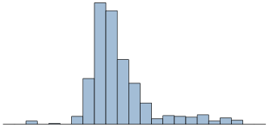

NOTE: figure/graphic rendered as an image from the PDF; its content is not machine-readable text. Caption (if any) follows as the next block.

To test these conjectures, we allow game-specific streaming elasticities β(*xj*) to vary with game attributes *xj*. The attributes *xj* include the publisher size, game age, Metacritic rating, standard deviation of consumer ratings, and regular price. The game’s age and pub lisher size serve as proxies for consumer awareness prior to seeing the game in live streams. Consumers may be unaware of new games or those released by small publishers, which have limited marketing bud gets and do not advertise as broadly as major game conglomerates. We define “small publishers” as those that have released two games or fewer, which corre sponds to the median number of released titles.

The Metacritic rating measures the game’s appeal to the average consumer. Conditional on the average critic rating, a high standard deviation of customer rat ings indicates “niche” games that strongly appeal to some consumers with specific tastes.<sup>22</sup>

We also include the game’s regular price in *xj* because it may affect consumers’ purchase decisions once they become aware of the game or learn its quality or match value from live streams. Controlling for price enables us to isolate the incremental effects of other attributes, helping us to more cleanly test the conjectures outlined above.

Following Athey et al. (2019), we use GRF to estimate streaming elasticities β(*xj*). We use local moment condi tions to generalize our IV strategy from Section 3.2. The main advantage of GRF is that they allow us to project streaming elasticities onto multiple game attributes, allowing us to study how streaming elasticities vary with each attribute in *xj* while holding all other attri butes constant. In estimation, we fix the persistence parameter δ at the level estimated in Table 3 because the grf R package we use can only estimate linear spe cifications. We relegate estimation details and robust ness checks to Online Appendix D. To ensure that our conclusions are not driven by the model’s functional form assumptions, in Online Appendix D.1, we esti mate streaming elasticities using univariate median splits instead of GRF and show that our qualitative results remain unchanged.

**4.2. Estimates of Heterogeneous Streaming Effects** Figure 4 shows the distribution of the estimated elastici ties <sup>ˆ</sup>β(*xj*). The average estimated elasticity across games is 0.022, which is similar to our average elasticity esti mate at 0.027 in Table 3. Further, we estimate a substan tial heterogeneity in streaming effects across games. The

estimated elasticities vary between –0.112 and 0.156, with the interquartile range from 0.005 to 0.029. The dis tribution is visibly skewed toward zero, implying that for most games, live streams bring few additional players into the game. Nevertheless, live streams gener ate positive effects for 88% of games in our sample, sug gesting that in most cases, watching Twitch does not distract consumers from playing games. Instead, consu mers seem to perceive playing games and watching them in live streams as complementary activities.

Next, we explore how the estimated elasticities vary with the attributes *xj*. We describe key patterns here and relegate details to Online Appendix D. The left graph in Figure 5 visualizes streaming effects by game age and publisher size. We find that games by small publishers benefit more from Twitch live streams than games released by larger publishers. Specifically, conditional on the average values of all other attributes, streaming elasticities are 27% higher for games released by small publishers than for those released by larger publishers. Our results are more nuanced for game age: We find streaming elasticities to be nonlinear in the number of years since the game’s release.<sup>23</sup>

The right graph in Figure 5 visualizes the estimated elasticities by Metacritic rating and the standard devia tion of consumer ratings. We find larger streaming effects for highly rated games. For instance, games rated above the median rating of 80/100 have a stream ing elasticity of 0.039, approximately 97% higher than the streaming elasticity for games rated below 80/100. Further, conditional on the critic rating, games with standard deviations of consumer ratings above 2.8 sig nificantly benefit more from Twitch live streams. For these games, we estimate the streaming elasticity of 0.054, more than twice as high as that for games with lower standard deviations of consumer ratings.

Lastly, we find that streaming elasticities are higher for inexpensive games, indicating that consumers are

**Figure 4.** (Color online) Distribution of Streaming Elasticities

*Notes.* This figure visualizes the distribution of estimated streaming elasticities <sup>ˆ</sup>β(*xj*) from the generalized random forests (GRF). See Sec tion 4 and Online Appendix D.2 for details of our GRF estimation procedure.

**Huang and Morozov:** *Promotional Effects of Live Streams by Twitch Influencers* 926 Marketing Science, 2025, vol. 44, no. 4, pp. 916–932, © 2025 INFORMS

Page 12

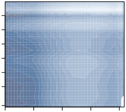

NOTE: figure/graphic rendered as an image from the PDF; its content is not machine-readable text. Caption (if any) follows as the next block.

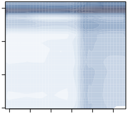

NOTE: figure/graphic rendered as an image from the PDF; its content is not machine-readable text. Caption (if any) follows as the next block.

more likely to play the broadcasted game if it is avail able at a low price (see Online Appendix Figure 15).

Put together, we find live streaming effects to be the highest for games by small publishers, highly rated games, and games with niche appeal. These findings support our conjecture that live streams make consu mers aware of the games by lesser-known publishers and reveal the game’s quality and match value. In the next section, we study how these estimated elasticities translate into the profitability of sponsored live streams.

**5. ROI of Sponsored Live Streams 5.1. ROI Calculation** Consider a publisher that hires a top streamer to broadcast the game on Twitch. In this section, we provide simple back-of-the-envelope calculations to assess the profitabil ity of such sponsorships for the games in our sample.

We compute the ROI of an hour-long sponsored live stream for game *j* as follows:

ROI*j*

∆Purchase*j* × Profit Margin*j* Sponsorship Fee

Sponsorship Fee ,

(4)

where ∆Purchase*j*  ∆Players*j* × Conversion Rate is the number of new purchases generated by the spon sored live stream, which equals the number of players brought into the game by the live stream (∆Players*j*) times the share of these players who purchase the game (“Conversion Rate”); Profit Margin*j* is the dollar amount that the publisher earns from selling each game copy; and Sponsorship Fee is the hourly fee paid by the publisher.

Because Steam charges a 30% commission fee, we set Profit Margin*j*  70% · Price*j* where Price*j* is game *j*’s

To compute ROI in Equation (4), we still need to cal culate the number of additional players brought into the game, ∆Players*j*, and we need to estimate how many of these additional players will purchase the game. To sim plify computations, we consider a hypothetical “steady state” in which the publisher hires a streamer to perma nently broadcast the game live on Twitch for a fixed hourly sponsorship fee.<sup>25</sup> The next few sections explain how we predict the effect of sponsored streams on game usage under this steady state assumption.

**5.2. Are Sponsored and Organic Streams Equally Effective?** Most streams in our data are *organic* in the sense that streamers broadcast games without getting paid, whereas relatively few are streams *sponsored* by pub lishers. The effects of sponsored streams might differ from those of organic streams. For example, sponsored streams might be less effective than organic streams if consumers see them as advertising and thus perceive

**Figure 5.** (Color online) Estimated Streaming Elasticities from Generalized Random Forests

*Note.* These graphs visualize the estimated function <sup>ˆ</sup>β(*xj*) for two game attributes at a time while holding all other attributes *xj* fixed at their aver age levels.

**Huang and Morozov:** *Promotional Effects of Live Streams by Twitch Influencers* Marketing Science, 2025, vol. 44, no. 4, pp. 916–932, © 2025 INFORMS 927

Page 13

them as less trustworthy (Ershov and Mitchell 2020, Pei and Mayzlin 2022).

We extend Equation (1) by allowing sponsored and organic streams to affect the number of players differ ently. We model the number of players in game *j* at time *t* as

log(1 + Players*jt*)

 β*<sup>org</sup>* · log(1 + *V<sup>org</sup>*

**equation / math rendering (image)**

NOTE: contains mathematical notation; text above is the PDF text layer and symbols may be mis-extracted. Image shows the original.

[output not shown]

**equation / math rendering (image)**

NOTE: contains mathematical notation; text above is the PDF text layer and symbols may be mis-extracted. Image shows the original.

β*<sup>spons</sup>*

· log(1 + *V<sup>spons</sup> jt* (δ))

**equation / math rendering (image)**

NOTE: contains mathematical notation; text above is the PDF text layer and symbols may be mis-extracted. Image shows the original.

+ λ*j*, *d*(*t*) + *µj*, *h*(*t*) + η*t* + ε*jt*, (5)

**equation / math rendering (image)**

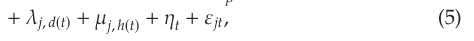

NOTE: contains mathematical notation; text above is the PDF text layer and symbols may be mis-extracted. Image shows the original.

where *V<sup>org</sup>*

*jt* and *V<sup>spons</sup>*

*jt* are the cumulative viewership stocks of *organic* and sponsored streams, β*<sup>org</sup>*is the organic streaming elasticity, β*<sup>spons</sup>*  ω · β*<sup>org</sup>*is the spon sored streaming elasticity, and other fixed effects are the same as in equation (1). We expect to find ω *<* 1 if sponsored streams are less effective than organic ones. We also estimate a common persistence parameter δ. To estimate the model, we extend our identification and estimation strategy from Section 3 (see Online Appendix E.1 for details).

The results are reported in Online Appendix Table 8. We estimate the organic streaming elasticity to be

ˆβ

As we show in Online Appendix E.2, organic and sponsored streams produce comparable increases in viewership despite their drastically different effects on the number of players. We conjecture that top strea mers always attract large audiences due to their unique styles and entertaining content, regardless of their sponsorship status. However, consumers may trust only the unbiased opinions from organic streams when deciding whether to play the broadcasted game, dis counting sponsored streams as previously conjectured.

An important caveat is that game publishers may strategically choose which games to sponsor and when to sponsor them. To make organic and sponsored elasticities more comparable, we obtain our estimates using the subsample of 272 games that are sponsored at least once in our data. One might still worry that publishers only sponsor live streams during periods when such sponsorships are most likely to be effective. Therefore, one should interpret the sponsored elasticity β*<sup>spons</sup>*as reflecting the effect of sponsored live streams in the “best-case scenario” rather than for the average game in a typical time period.

**5.3. How Do Sponsored Streams Affect Game Usage?** To compute the increase in the number of players, ∆Players*j*, we first calculate the initial effect of the sponsored stream. Absent the sponsored stream, the game *j* is in a steady state with the number of players, Players<sup>0</sup>

*j* <sup>; the number of viewers, Viewers</sup><sup>0</sup>

*j* <sup>; and the</sup> baseline stock of viewership, *V*<sup>0</sup>

*j* <sup>. We assume the base</sup> line values of the first two variables are equal to the average number of players and viewers of that game in our sample.

In Online Appendix E.2 (column 1 of Online Appen dix Table 9), we show that the sponsored stream increases the number of viewers by 2,559, which allows us to compute the new viewership level and viewership stock, Viewers<sup>1</sup>

*j* <sup>and</sup>*<sup>V</sup>*<sup>1</sup>

*j* <sup>. This increase in the viewership</sup> stock lifts the number of players with the sponsored elasticity β<sup>spons</sup>

*j* . Based on our computations in Online Appendix E.1, we set β<sup>spons</sup>

*j*  ˆω · <sup>ˆ</sup>β(*xj*), where ˆω  0*:*173 is the estimated sponsored elasticity factor, and <sup>ˆ</sup>β(*xj*) is the estimated organic streaming elasticity obtained from the GRF estimation in Section 4. This elasticity enables us to compute the new player count, Players<sup>1</sup>

*j* and therefore the difference ∆Players*j*  Players<sup>1</sup>

*j* Players<sup>0</sup>

*j* <sup>, which reflects the effect of the sponsored live</sup> stream on game usage.

**5.4. How Do Live Streams Affect Game Sales?** We have shown in Sections 3 and 4 that Twitch live streams attract additional players into the broadcasted games. Some of these are new players who need to pur chase the game, whereas others might be returning players who already own it. Because publishers pri marily earn their revenues on Steam from selling new game copies, we need to separate these two channels.

In Online Appendix E.4, we decompose the esti mated streaming elasticities using individual-level data from the Comscore panel. We estimate whether watch ing a game on Twitch makes the consumer more likely to buy this game on Steam within the same hour. The main identification challenge is that of reserve causality: Consumers may watch Twitch streams because they have already decided to buy the game. To address this concern, we use an instrumental variable strategy simi lar to the one in Section 3, leveraging the variation in the broadcast hours of each consumer’s “favorite” (most frequently watched) streamer. See Online Appen dix E.4 for details.

We find that watching a game on Twitch increases the probability of buying that game on Steam by 0.0016. This estimate implies that 1,000 additional Twitch view ers generate 1.6 game purchases. Combining this esti mate with the streaming elasticity from Table 3, we obtain that among all additional players brought into the game by a Twitch stream, 37% are new players who

**Huang and Morozov:** *Promotional Effects of Live Streams by Twitch Influencers* 928 Marketing Science, 2025, vol. 44, no. 4, pp. 916–932, © 2025 INFORMS

Page 14

purchase a game copy, and 63% are returning players who already own the game. Based on these results, we fix the conversion rate in Equation (4) at 37%. Although we limit this analysis to Steam game purchases to remain consistent with our Steam game usage data, our results change little when we include purchases from other major online retailers (see Online Appendix Table 10).

An important caveat is that we use individual-level data on game sales and Twitch viewership from Com score. As explained in Section 2.6, this sample contains a small panel of 8,611 consumers, which might not be fully representative of the average Twitch viewer, includes only 203 of 599 games covered in the main sample and spans the period of 2019–2020, preceding our main sam ple period. Despite these limitations, individual-level data on Twitch viewership and transactions enable us to obtain suggestive estimates of how Twitch live streams affect online game purchases. This is the only analysis in the paper that uses Comscore data.

**5.5. ROI Estimates** Figure 6 visualizes the distribution of the expected dollar revenues per hour of sponsoring a live stream, computed from Equation (4). We find the median effect of sponsor ship on revenues to be only $7.66, far below the estimated sponsorship fee of $144. These estimates imply a median ROI of 95%.<sup>26</sup> Further, sponsored streams are only prof itable for 16% of games in our sample. That is, we esti mate a negative ROI from sponsored streams for the vast majority of games, suggesting that sponsored promotions are not worth the investment in most cases.

Nevertheless, we find ROI estimates to be vastly dif ferent across games. For example, at the 90th percentile of the revenue distribution, sponsored streams increase

the expected revenue by $339, implying an ROI of 135%. This right tail includes games for which we esti mated high streaming elasticities β(*xj*) in Section 4, including games by small publishers, highly rated games, and games with niche appeal.

**5.6. Managerial Implications** Our results have several managerial implications regard ing the effects live stream promotions in the video game industry. First, practitioners should avoid placing too much weight on the commonly reported anecdotes in which sponsored live streams supposedly generated high ROI. We speculate that these anecdotes originate at companies that actually promote their products in live streams and obtain positive returns. This selective report ing could inflate the ROI estimates covered in the media. For example, if we focused on game publishers sponsor ing live streams in our sample and assumed they report their ROI only if it is positive, the median reported ROI would be 243%, which is very different from the actual median ROI of 95% in our estimates.

In our analysis, we move beyond these anecdotes and estimate the entire distribution of live streaming effects. These estimates paint a more complete picture: Although sponsored live streams are profitable for some games, they generate negative ROI for most games in our sample. An important implication is that practitioners seeking to promote their titles in live streams in this industry should rely on rigorous esti mates of promotion effects rather than on selectively reported success stories.

Second, practitioners should carefully choose which video games to promote via live streams. Our results imply that, conditional on price, sponsored live streams might be especially effective for games that benefit from long-format demonstrations. This includes high-quality games praised by critics and niche games that strongly appeal to some consumers. Therefore, by carefully choosing which games to sponsor, publishers can maxi mize the expected ROI from their sponsorships and avoid the negative profit scenarios in Figure 6. Addition ally, small publishers might find sponsored live streams more profitable because their games exhibit larger streaming effects. Because small publishers often lack the resources to run large-scale advertising campaigns, they may find it helpful to sponsor live streams as a cost-effective way to increase consumer awareness.

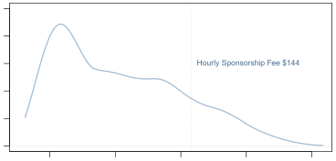

NOTE: figure/graphic rendered as an image from the PDF; its content is not machine-readable text. Caption (if any) follows as the next block.

Finally, practitioners should consider alternative ways of generating live streaming content. We show that organic live streams are about six times as effective as sponsored streams at bringing players into broadcasted games. Therefore, if publishers can incentivize influen cers to stream the game organically, such promotions could be a lot more profitable than sponsorships. In fact, some publishers have already experimented with such promotion campaigns. A recent example of this strategy

**Figure 6.** (Color online) Revenue Increase from a Sponsored Twitch Stream

*Notes.* This figure shows the expected dollar revenues per hour of spon soring a live stream across 519 paid games in our sample. We plot a ker nel density estimate that uses Epanechnikov kernel with the default bandwidth. The predicted revenues correspond to the first term in the numerator of the ROI Equation (4), ∆Purchase*j* × Profit Margin*j*. The graph shows the distribution of the expected revenues computed from Equation (4).

**Huang and Morozov:** *Promotional Effects of Live Streams by Twitch Influencers* Marketing Science, 2025, vol. 44, no. 4, pp. 916–932, © 2025 INFORMS 929

Page 15

is Amazon Games that offered influencers in-game perks for playing its new game “Lost Ark” live on Twitch. If other publishers can take a page out of Amazon’s play book and incentivize organic live streams in similar ways, they may be able attract new players and increase game sales while avoiding the hefty sponsorship fees.

**6. Conclusion** In this paper, we collect novel high-frequency data on video game live streams by Twitch influencers and evalu ate how live streams affect the popularity of broadcasted games. Using plausibly exogenous variation in the broad cast hours of Twitch influencers, we show that live streams generate a small and short-lived increase in the number of players. We then estimate the heterogeneity in live streaming effects as a function of game attributes, which reveals that Twitch live streams make consumers aware of games by lesser-known publishers and inform consumers about the game’s quality and match value. Lastly, we provide back-of-the-envelope ROI calcula tions showing that relatively few games derive positive returns from sponsoring live streams on Twitch.

Another limitation of our ROI analysis is that, because of the nature of our data and empirical strategy, we focus on measuring the short-term effects of live streams. This limitation might be important for two reasons. First, we do not account for purchases made long after the stream. For example, a consumer might buy the game as a Christmas gift several months after seeing it on Twitch. Because our elasticity estimates do not capture these long-term effects, our analysis might be understating the positive effects of Twitch live streams on game sales. Sec ond, publishers may sponsor live streams to build their games into recognizable titles, attempting to spark more interest in the game and foster a strong online fan com munity. If publishers pursue these long-term goals, our estimates may understate the perceived benefits from sponsorships. An important direction for future research

would be to estimate these long-term effects of spon sored live streams. We look forward to seeing future work in this area.

**Acknowledgments** The paper was previously circulated with the title “Video Advertising by Twitch Influencers.” The authors thank Gio vanni Compiani, Jean-Pierre Dub´e, Brett Gordon, Avery Haviv, Wes Hartmann, Przemyslaw Jeziorski, Minkyung Kim, Yewon Kim, Ivan Li, Nan Li, Mitch Lovett, Davide Proserpio, Stephan Seiler, Andrey Simonov, Anna Tuch man, Jeremy Yang, as well as seminar and conference parti cipants at the University of California Riverside, University of Delaware, University of Houston, Hong Kong University of Science and Technology, the 2021–2023 Marketing Sci ence Conferences, the 2022 Summer Institute for Competi tive Strategy, University of Rochester, Tilburg University, and the 2023 Workshop for Economics of Advertising and Marketing for their helpful comments and suggestions. The authors also thank James Ryan for excellent research assistance, and the authors thank John Johnson and Will Thompson for helping us access Comscore Data. All errors are our own. All authors certify that they have no affiliations with or involvement in any organi zation or entity with any financial interest or non-financial in terest in the subject matter or materials discussed in this manuscript. The authors have no funding to report.

#### **Endnotes**

**1** Mitsubishi unveiled its 2022 Outlander on Amazon Live, and a home appliance brand Delonghi partnered with influencers on Tik Tok Live to promote coffee machines. In 2020, a cosmetics brand L’Oreal started doing shoppable live streams that featured influen cers doing makeup tutorials.

**3** Practitioners report that sponsoring live streams of Grandma Wang on the platform Douyin (TikTok in China) yields an average ROI of 150%, whereas sponsoring influencer Li Xiaolu yields an average ROI of 230%, with ROI sometimes exceeding 300% for cer tain cosmetics products (Chen 2020).

**4** Li et al. (2024) leverage YouTube’s delays in video uploads and argue that these delays make it less likely that influencers can stra tegically shift their upload timing in response to contemporaneous demand shocks. They also control for serial correlation in demand shocks. Yang et al. (2021) present evidence that TikTok video upload timing is not primarily driven by temporary demand shocks.

**5** In this regard, our approach resembles the prior work on measuring the effects of TV ads using high-frequency data and discontinuity-in- time research designs (Liaukonyte et al. 2015, He and Klein 2023).

**6** These aggregate statistics are from twitchtracker.com, a thirdparty website that monitors the streaming activity on Twitch.tv and reports historical data going back to 2012. The reported statistics are for January 2022.

**7** See the Streamlabs and StreamHatchet Quarterly Report for Q3 (May 2020). The Chinese market for video game streaming has grown rapidly over the past years and reached around 71.3 million monthly active users, with Douyu and Huya controlling the largest market shares (source: Statista.com). Thus, the video game streaming

**Huang and Morozov:** *Promotional Effects of Live Streams by Twitch Influencers* 930 Marketing Science, 2025, vol. 44, no. 4, pp. 916–932, © 2025 INFORMS

Page 16

market in China is catching up with the western market, where the largest platform, Twitch, has approximately 140 million monthly active users (Shewale 2023).

**9** Because of local server maintenance, our API calls were inter rupted from June 30 to July 11, 2021. Therefore, these days are miss ing from our main sample.

**10** A Spanish streamer, Ibai, for example, peaked at 1,538,645 active viewers by streaming a series of boxing matches that featured other Spanish streamers, establishing a viewership record in our sample.

**11** See “Steam 2020 Year in Review” (Steamworks Development 2021).

**12** Many of these indie games have become remarkably popular and established a significant presence on Twitch. For instance, an indie game “Rocket League,” best described as “soccer, but with rocket- powered cars,” has become an internationally recognized esports game with prize pools reaching $6 million.

**13** Li (2023) shows that Twitch streamers sometimes use long stream titles to make the sponsorship label appear less prominent. We do not distinguish whether these disclosures are prominent in our application.

**14** An important data limitation is that streamers self-select into dis closing subscription counts on twitchtracker.com, which might intro duce selection bias. Nevertheless, our hourly income estimate of $144 is close to the standard hourly sponsorship fee of $100 reported on Twitch’s platform “Bounty Board” (see Online Appendix Figure 11).

**15** Ideally, we would observe life events that prevent streamers from following regular broadcast schedules. Because we do not observe such events, we cannot directly use them as instruments.

**16** Although we do observe a slight growth in the number of players before the start of the focal stream, this pretrend is mild compared to the abrupt increase in players one to two hours after the stream starts.

**17** Streamers that broadcast a Steam game mechanically increase the number of players Players*jt* in this game, which might be particu larly problematic for games with few players. To address this issue, we subtract the number of live top streamers from Players*jt*, which removes the direct effect of the instrument ˜*zjt*.

**18** Note that if *t* is the last hour of the day *d*, then *zj*,*d*(*t*) includes lagged instruments *zjt* for all 24 hours of that day and 12 hours prior to the first hour of that day.

**19** When a live stream increases viewership Viewers*j*,*t* from 1,137 to 3,421, Equation (1) predicts that log(1 + Players*jt*) should increase by ˆβ · ∆log(1 + Viewers*j*,*t*) ≈0*:*030, which implies that the number of players Players*jt* should increase from 5,521 to (1 + 5,521) · exp(0*:*030) 1 ≈5,687.

**20** This idea parallels several papers in the advertising literature that studied the effects of advertising on awareness (Honka et al. 2017, Tsai and Honka 2021).

**21** In this sense, live streams may generate effects similar to those of informative ads (Grossman and Shapiro 1984, Ackerberg 2003, Mor ozov and Tuchman 2024).

**22** Bar-Isaac et al. (2012) model “niche” products as having designs that lead to a higher variance of consumers’ match values. One can interpret the standard deviation of customer ratings in our applica tion as a proxy for the unobserved distribution of match values.

**23** We find the largest streaming elasticities ˆβ for games that are about eight years old. One possible explanation is that Twitch streams make consumers aware of the games forgotten by the cur rent generation of players. Indeed, because about a quarter of Twitch viewers are between 16 and 24 years old, in 2021, many of them had not yet reached the legal age when these older games were launched (Statistica 2022).

**24** We remove 80 free games from our sample and keep only the remaining 599 80  519 paid games. Free games mostly bring rev enues in the form of microtransactions, such as the purchases of additional levels and characters, which we do not observe.

**25** Alternatively, we could assume that the sponsored live stream lasts one hour and compute the resulting lift in the game’s usage in that hour, one hour later, two hours later, and so on. Although we do not expect this alternative approach to change our qualitative results, it would likely yield even lower ROI estimates than our pre ferred approach because the lift in the number of players, ∆Players*j* would not depend on persistent streaming effects that remain from the previous hours of live streaming.

**26** Blake et al. (2015) similarly find an ROI of –63% for eBay’s spon sored search ads on Google.

**References** Ackerberg DA (2003) Advertising, learning, and consumer choice in

experience good markets: An empirical examination. *Internat. Econom. Rev.* 44:1007–1040. Arora A, Glaser D, Kim A, Kluge P, Kohli S, Sak N (2021) It’s show

time! How live commerce is transforming the shopping experi ence. *McKinsey Digit* (July 21), https://www.mckinsey.com/ capabilities/mckinsey-digital/our-insights/its-showtime-how- live-commerce-is-transforming-the-shopping-experience. Athey S, Tibshirani J, Wager S (2019) Generalized random forests.

*Ann. Statist.* 47:1148–1178. Bar-Isaac H, Caruana G, Cu˜nat V (2012) Search, design, and market

structure. *Amer. Econom. Rev.* 102:1140–1160. Blake T, Nosko C, Tadelis S (2015) Consumer heterogeneity and

paid search effectiveness: A large-scale field experiment. *Econo metrica* 83:155–174. Chen T (2020) Douyin live-streaming case studies: ROI and sales

data. *walkthechat.com* (May 3), https://walkthechat.com/douyinlive-streaming-case-studies-roi-and-sales-data/. *Federal Trade Commission* (2019) FTC releases advertising disclosures

guidance for online influencers. (November 5), https://www. ftc.gov/news-events/news/press-releases/2019/11/ftc-releases- advertising-disclosures-guidance-online-influencers. Cong Z, Liu J, Manchanda P (2021) The role of live in livestreaming

markets: Evidence using orthogonal random forest. Preprint, submitted July 4, https://arxiv.org/abs/2107.01629. Ershov D, Mitchell M (2020) The effects of influencer advertising

disclosure regulations: Evidence from Instagram. *Proc. 21st ACM Conf. Econom. Comput.* (ACM, New York), 73–74. Grossman GM, Shapiro C (1984) Informative advertising with dif

ferentiated products. *Rev. Econom. Stud.* 51:63–81. He C, Klein TJ (2023) Advertising as a reminder: Evidence from the

Dutch State Lottery. *Marketing Sci.* 42:892–909. Honka E, Hortac¸su A, Vitorino MA (2017) Advertising, consumer

awareness, and choice: Evidence from the US banking industry. *RAND J. Econom.* 48:611–646. Katz A (2023) Cable news ratings for November 2023. *AdWeek*

(December 5), https://www.adweek.com/tvnewser/week-ofnov-27-cable-ranker-powered-by-desantis-newsom-primetime- debate-fox-news-is-most-watched-cable-network/. Li I (2023) Sponsorship disclosure and reputation in the creator

economy: Evidence from twitch. Working paper, Stanford Uni versity, Stanford, CA. Li N, Haviv A, Lovett MJ (2025) Opposing influences of YouTube

influencers: Purchase and usage effects in the video game indus try. *Marketing Sci.*, ePub ahead of print January 28, https://doi. org/10.1287/mksc.2021.0242. Liaukonyte J, Teixeira T, Wilbur KC (2015) Television advertising

and online shopping. *Marketing Sci.* 34:311–330.

**Huang and Morozov:** *Promotional Effects of Live Streams by Twitch Influencers* Marketing Science, 2025, vol. 44, no. 4, pp. 916–932, © 2025 INFORMS 931

Page 17

Lin Y, Yao D, Chen X (2021) Happiness begets money: Emotion and

engagement in live streaming. *J. Marketing Res.* 58:417–438. Lu S, Yao D, Chen X, Grewal R (2021) Do larger audiences generate

greater revenues under pay what you want? Evidence from a live streaming platform. *Marketing Sci.* 40:964–984. May E (2020) Streamlabs & Stream Hatchet Q3 2020 live streaming

industry report. *Stream Labs* (October 8), https://blog.streamlabs. com/streamlabs-stream-hatchet-q3-live-streaming-industry-report- a49adba105ba. Morozov I, Tuchman A (2024) Where does advertising content lead you?

We created a bookstore to find out. *Marketing Sci.* 43(5):986–1001. Pei A, Mayzlin D (2022) Influencing social media influencers

through affiliation. *Marketing Sci.* 41:593–615. Shapiro BT, Hitsch GJ, Tuchman AE (2021) TV advertising effective

ness and profitability: Generalizable results from 288 brands. *Economertica* 89:1855–1879. Shewale R (2023) Twitch statistics for 2024. *Demand Sage*. Accessed

December 17, 2023, https://www.demandsage.com/twitchusers/.

Simonov A, Ursu RM, Zheng C (2023) Suspense and surprise in media

product design: Evidence from twitch. *J. Marketing Res.* 60:1–24. Staiger D, Stock JH (1997) Instrumental variables regression with

weak instruments. *Econometrica* 65:557–586. Statista (2022) Distribution of Twitch.tv users worldwide as of May

2022, by age group. Accessed January 31, 2025, https://www. statista.com/statistics/634057/twitch-user-age-worldwide/. Steamworks Development (2021) Steam 2020 year in review. *Steam*

*Community* (January 13), https://steamcommunity.com/groups/ steamworks/announcements/detail/2961646623386540827. Tsai Y-L, Honka E (2021) Informational and noninformational

advertising content. *Marketing Sci.* 40:1030–1058. Vincent J (2018) Drake drops in to play Fortnite on Twitch and breaks

the record for most-viewed stream. *The Verge* (March 15), https:// www.theverge.com/2018/3/15/17123424/ninja-drake-fortnite- twitch-stream-record-travis-scott-juju. Yang J, Zhang J, Zhang Y (2021) Engagement that sells: Influencer

video advertising on TikTok. Preprint, submitted March 30, https://dx.doi.org/10.2139/ssrn.3815124.

**Huang and Morozov:** *Promotional Effects of Live Streams by Twitch Influencers* 932 Marketing Science, 2025, vol. 44, no. 4, pp. 916–932, © 2025 INFORMS

Page 18